# DES_part5_03735990

## Verification

```python
# Verification

%run "part5_tests"
```

```
.
----------------------------------------------------------------------
Ran 1 test in 0.745s

OK
```

## Simulation Study IV

### Task 5.2.1: Multiple Runs Confidence

```python
# Task 5.2.1 Multiple Runs Confidence
import part5_simstudy

part5_simstudy.task_5_2_1()
```

```
Blocking Probability for 100.0 sec : and alpha : 0.1 is : 0.11581830084936205
Blocking Probability for 100.0 sec : and alpha : 0.05 is : 0.11461526394639868
Blocking Probability for 1000.0 sec : and alpha : 0.1 is : 0.12652185477120595
Blocking Probability for 1000.0 sec : and alpha : 0.05 is : 0.12558699402109189
SIM TIME:  100s; ALPHA: 10%; NUMBER OF RUNS: 4238; TOTAL SIMULATION TIME (SECONDS): 423800
SIM TIME:  100s; ALPHA:  5%; NUMBER OF RUNS: 6009; TOTAL SIMULATION TIME (SECONDS): 600900
SIM TIME: 1000s; ALPHA: 10%; NUMBER OF RUNS:  468; TOTAL SIMULATION TIME (SECONDS): 468000
SIM TIME: 1000s; ALPHA:  5%; NUMBER OF RUNS:  660; TOTAL SIMULATION TIME (SECONDS): 660000
```

```
[4238, 6009, 468, 660]
```

### Task 5.2.2: Batch Confidence

```python
# Task 5.2.2 Batch Confidence
import part5_simstudy

part5_simstudy.task_5_2_2()
```

```
Blocking Probability for batch size : 100 alpha : 0.1 is : 0.12099794172056899
Blocking Probability for batch size : 100 alpha : 0.05 is : 0.1214672052812792
Blocking Probability for batch size : 1000 alpha : 0.1 is : 0.12568921485166737
Blocking Probability for batch size : 1000 alpha : 0.05 is : 0.12547003501777287
BATCH SIZE:  100; ALPHA: 10%; TOTAL SIMULATION TIME (SECONDS): 447331.27185857255
BATCH SIZE:  100; ALPHA:  5%; TOTAL SIMULATION TIME (SECONDS): 635867.0532800833
BATCH SIZE: 1000; ALPHA: 10%; TOTAL SIMULATION TIME (SECONDS): 514338.8634657856
BATCH SIZE: 1000; ALPHA:  5%; TOTAL SIMULATION TIME (SECONDS): 723459.54908141
```

```
[447331271.85857254, 635867053.2800833, 514338863.46578556, 723459549.08141]
```

### Task 5.2.4: Confidence Plots II

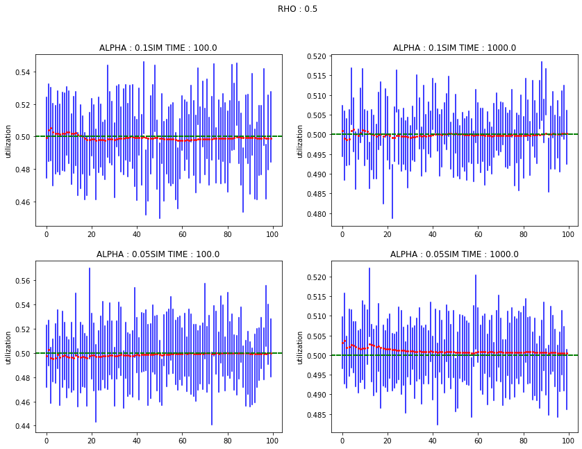

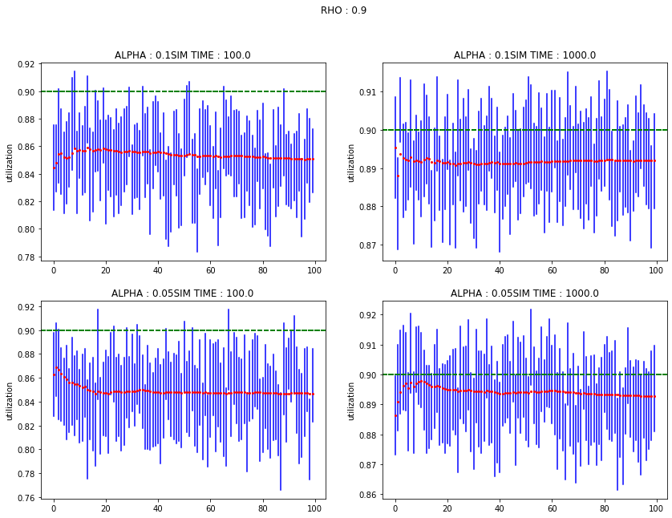

```python
# Task 5.2.4 Confidence Plots II

import part5_simstudy
part5_simstudy.task_5_2_4()
```

## 5.3 Analysis and General Questions

### Task 5.3.1: Confidence Interval Width

Firstly we observe that we need more runs when we decrease alpha, which is an expected result as we need to more values to fall closer to each other and as we have established in the previous assignments, the variance of the blocking probability decreases over time. Having lower aplha is like having a stricter limit on the variace of the blocking probabilities and hence we see that it takes more time/runs. We see that the overall time needed to reach a certain confidence interval is more or less the same even with smaller batches or smaller simulation time (for the same alpha). However, for part 5.2.2 we always require more time than 5.2.1 because in 5.2.1 we start each run with an empty buffer(transient phase) and the blocking probability of the initial packets will be less. This same reason can be applied to explain why the time required to reach the confidence interval is more for higher simulation time or higher batch sizes. The disadvantage of the method in Task 5.2.1 is that we have a transient phase in each simulation run. The variance in the blocking probability is higher in the transient phase hence it is not optimum as explained above. One solution can be to start with a filled buffer. The disadvantage of the method in Task 5.2.2 is that for higher RHO the blocking probabilities of consecutive packets get more correlated and hence we will not have independent runs. A solution to this can be to have "guard" patches between sample runs to make sure that the consecutive packets are uncorrelated.

### Task 5.3.2: Confidence Interval Width

The theoretical blocking probability for S=4 and RHO=0.9 is 0.126. I printed the mean blocking probability at the end of each test in each Task, we see that for a higher simulation time or higher batch size the calculated blocking probability is closer to the theoretical one. This is because the analytical formula is for a steady state which reaches after a long simulation time and hence we must siulate for longer time ( ideally infinite) to reach the exact steady state blocking probability.

### Task 5.3.4: Variable Simulation Time

It would be possible to check the BP, each time a packet is droped and see if it reaches inside the confidence interval, this will give us more granularity and our result will not have to be in multiples of 100 or 1000 seconds or 100 or 1000 runs. We will first have to ignore the first few values as the blocking probaiblity of the packets in the startup phase will anyways be lower. The other problem with this mehtod will be that blocking probabilities of consecutive packets are correlated and hence we would not have independent runs.

### Task 5.3.5: Bootstrapping

Bootstrapping is useful when we have a finite number of samples which we know re not out entire population size. In case of regulat confidence intervals, we assume that our sample is the entire population size and has according to the central limit theorem a normal or student-t distribution. However, if this is not the case we are introducing bias in our estimate. With bootstrapping we can reduce the effect of this bias. The bootstrap and regualr confidence intervals will be the same in case we take infinite bootstrap samples.